# Rmarkdown自学笔记

### 2.4.2 代码

R Markdown中，R代码有两种使用方式：行内代码和代码块。

**行内代码(inline code)**：位于一对反引号内部，以r开头，空一格，后面是R的表达式。行内代码可实现在Markdown文本书写的同时嵌入代码并运行结果。

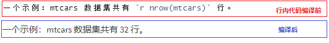

**R代码块(chunk)**：以三个反引号加{r}开始，再以三个反引号结束，作者可以在源文档中插入任意个代码块，代码块单独成段，文档渲染后代码运行结果显示在代码块后。代码块选项(chunk options)用来控制单个代码块的运行细节。

代码块选项设置：{r 代码名称，代码块选项}

给代码块命名的好处是：可在导航栏按名字浏览代码块，让代码生成的图形有意义地命名，避免在缓存中重复计算。<sup>4</sup>

**常见代码块选项及参数**：

- eval=FALSE：默认TRUE，当FALSE，只显示代码，不运行代码。

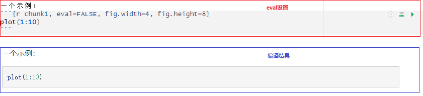

- echo=FALSE：默认TRUE，当FALSE，不显示代码，只显示运行结果。

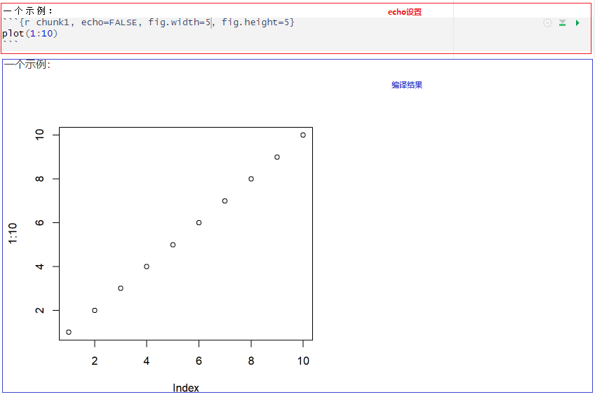

- include=FALSE：运行代码，不显示代码和运行结果，include = FALSE等价于echo = FALSE和results = ‘hide’。

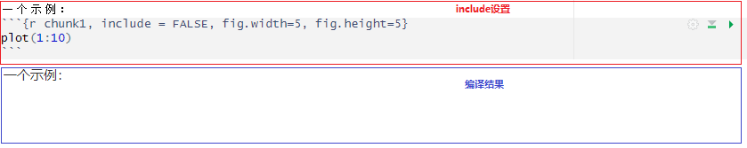

- collapse=TRUE：代码块结果放在一个文本块。

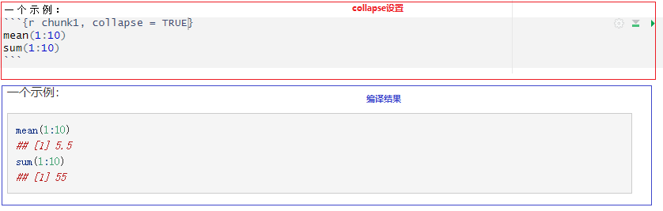

- results=“hide”：隐藏输出结果；选项results=选择文本型结果的类型。  
  makeup：默认选项，会把文本型结果变成HTML的原样文本格式；

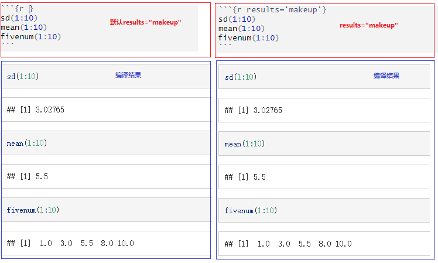

hide：隐藏代码块的运行结果。results=’hide’加上echo=FALSE等价于include = FALSE。

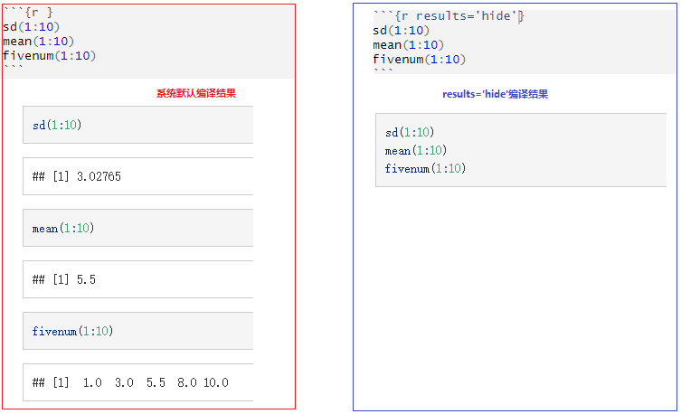

hold：一个代码块所有代码都显示完，才显示所有结果；

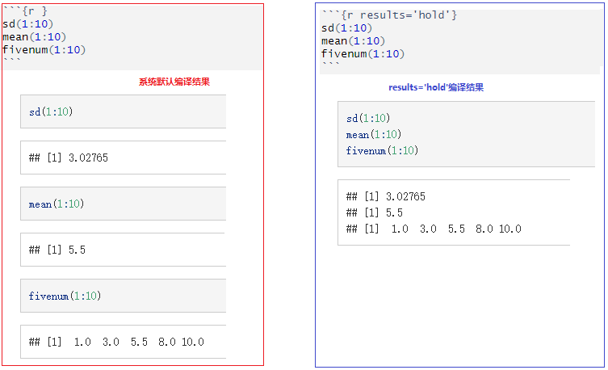

asis：文本型输出直接进入到HTML文件中，这需要R代码直接生成HTML标签，knitr包的kable()函数可以把数据框转换为HTML代码的表格。

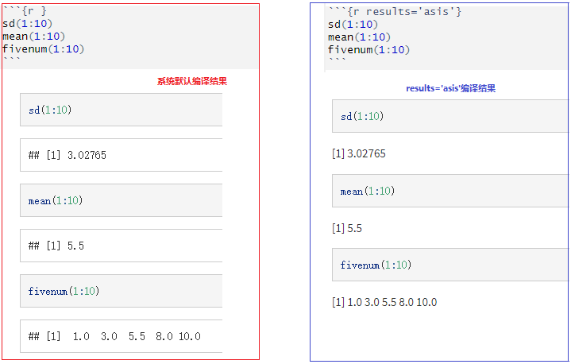

- prompt=TRUE代码用R的大于号提示符开始。如果希望结果不用#号保护，使用选项`comment=' '`。

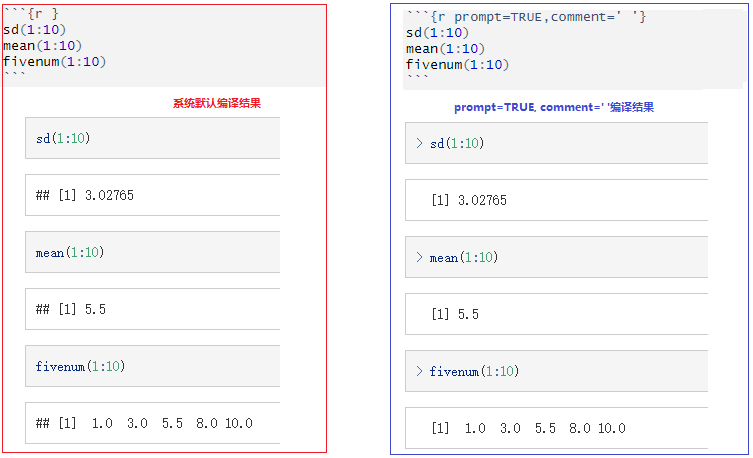

**其他设置：**  
- tidy=TRUE：整洁代码格式。  
- message=FALSE：不输出提示信息，比如包的载入信息。  
- warning=FALSE：不输出警告。  
- error=TRUE：忽略错误，继续编译文档。  
- cache=TRUE：缓存运行结果，能加速后续再编译。  
如果代码块涉及复杂的计算，cache=TRUE可以让knitr把运行结果保存为.rds文件，并在下次编译时略过计算过程，直接读取.rds 节省时间。只有代码块的内容发生变化时，knitr才会重新计算并更新.rds文件。有时knitr的缓存机制会让人难以预测代码是否重新运行，只推荐必要时使用。  
- fig.width, fig.height, fig.align, fig.cap：设置输出图形的宽和高（英寸）、对齐、标题。  
- out.width, out.height：设置输出图形的宽和高（百分比）。

**全局设置**  
若markdown内的代码块存在⼀样的参数设置，则可以提前设计好全局的代码块参数。全局代码块通过`knitr::opts_chunk$set`函数进行设置，⼀般设置在YAML文件下方。

`knitr::opts_chunk$set(代码块选项)`

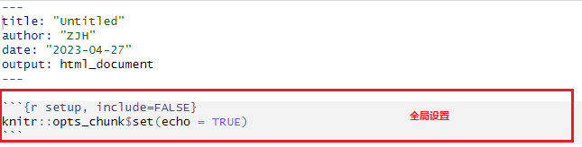